# Supervised learning in R

# Data description

```
[1] "Missing values check result : no missing values found"
```

## Variation

Given that most variables have few distinct values, we avoid having too many plots by using a proportion table to study data distribution. In passing this table gives information on the features classes. Histograms will be used for the distributions of absences and scores.

```
        Var   Class   Modality Proportion
     school  factor         GP       87.3
                            MS       12.7
        sex  factor          F       54.7
                             M       45.3
        age numeric         15       20.3
                            16       24.4
                            17       26.3
                            18       20.6
                            19        7.0
                            20        0.9
                            21        0.3
                            22        0.3
    address  factor          U       77.8
                             R       22.2
    famsize  factor        GT3       70.9
                           LE3       29.1
    Pstatus  factor          A       10.8
                             T       89.2
       Medu numeric          0        0.6
                             1       16.8
                             2       23.4
                             3       26.6
                             4       32.6
       Fedu numeric          0        0.6
                             1       21.8
                             2       28.5
                             3       24.7
                             4       24.4
       Mjob  factor    at_home       15.2
                        health        8.9
                         other       36.7
                      services       26.3
                       teacher       13.0
       Fjob  factor    teacher        7.0
                         other       55.7
                      services       27.8
                        health        4.1
                       at_home        5.4
     reason  factor     course       36.7
```

[output cut: 49 more lines]

```
       Dalc numeric          1       70.3
                             2       19.6
                             3        5.4
                             4        2.5
                             5        2.2
       Walc numeric          1       38.0
                             2       21.5
                             3       21.2
                             4       12.3
                             5        7.0
     health numeric          1       12.7
                             2       11.7
                             3       25.6
                             4       16.5
                             5       33.5
```

The features levels formatting is consistent within column. Most of the features reflect categorical variables. The coding of categorical variables is heterogeneous, some are coded with digits, other with strings. Some of the categorical variables are stored as numeric columns. This kind of numeric categorical variables from the right of the dataframe will stay numeric as they are Likert scale-like. Failures, study time and travel time cover different ranges but won’t be changed either as these ranges are log-like. Mother and father education cover uneven and not easily interpretable ranges, they will be converted to factors. Except for sex, most of the categorical variables have imbalanced classes. More specifically, ordered factors tend to be “right skewed”. Age, a numeric feature, is right skewed.

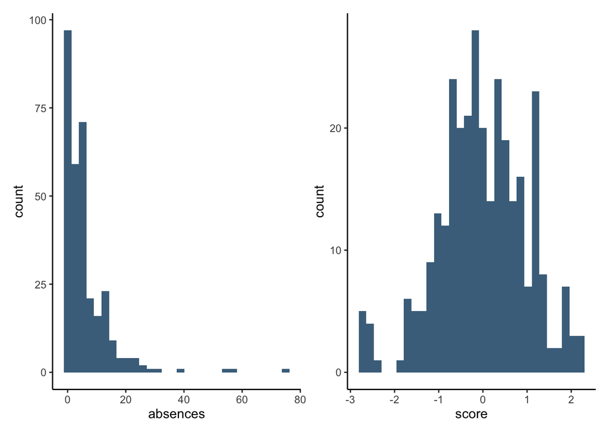

Absences is right skewed and will be log-transformed.It looks like score is already z-scaled.

## Associations

We have a significant number of predictors and a rather low number of records, hence feature selection is crucial. Correlations and, for categorical predictors, Chi square can help perform a manual feature filtering (during modelling, we will also apply automated methods of selection).

### Numerical features

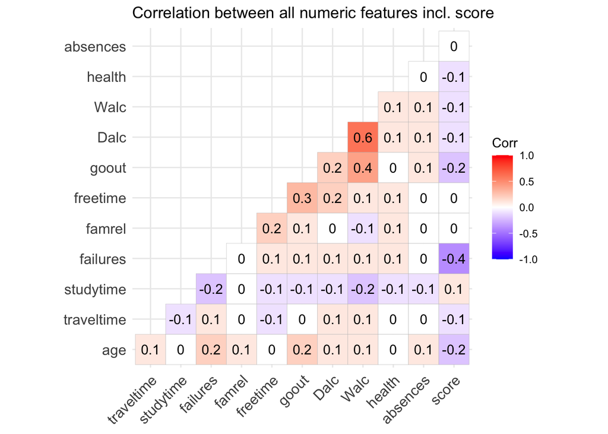

Most of the coefficients are very weak. Failures has the highest absolute correlation with score (the target) ; this feature will always be included in manual features filtering approaches. Regarding the correlations between predictors, Workday and Weekday alcohol consumption show a strong coefficient. Going out is moderately associated to Weekend alcohol consumption and weakly to freetime.

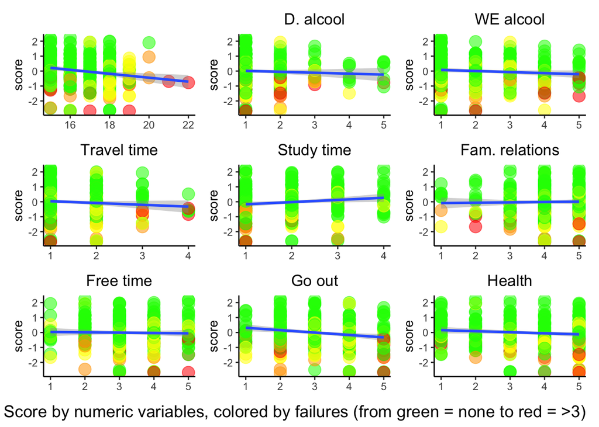

As suggested by the correlations, most columns don’t have a strong linear relation with the target column. The oldest students mechanically have a lot of failures. Failures are less frequent in high studytime groups and in low freetime groups.

### Categorical variables

```
 factor1  factor2
  school  address
 address internet
    Mjob     Fjob
    Mjob internet
  reason     paid
  famsup     paid
```

Based on Chi2, we found 6 pairs of highly significantly (p < 0.001) contingent factors (see above).

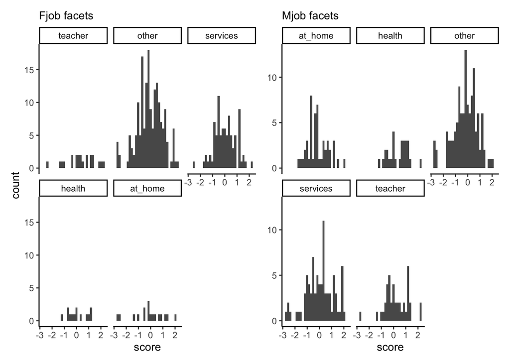

Father’s job is highly contingent with mother’s job and is sparse (most of fathers work in services or other). For the manual filtering approach, we keep only mother’s job.

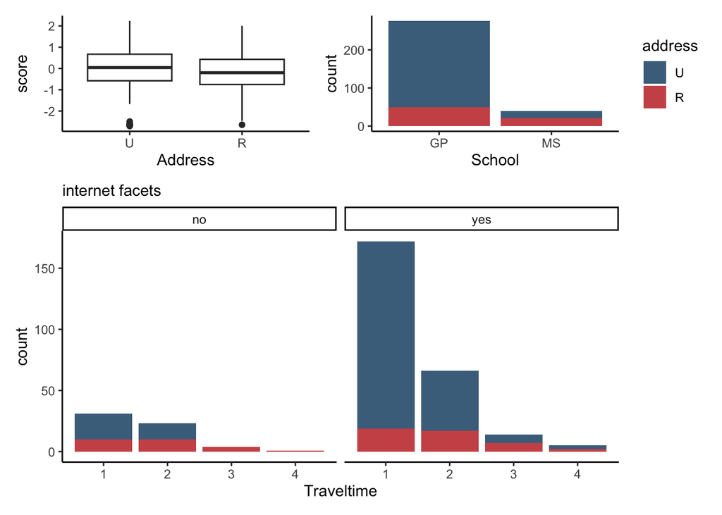

The effect of address on score isn’t obvious. GP school has a high majority of urban students, while MS school is mixed. As travel time increases, the proportion of rural increases. The proportion of students without internet is bigger among the rural. Overall, address won’t be included in manual filtering approach.

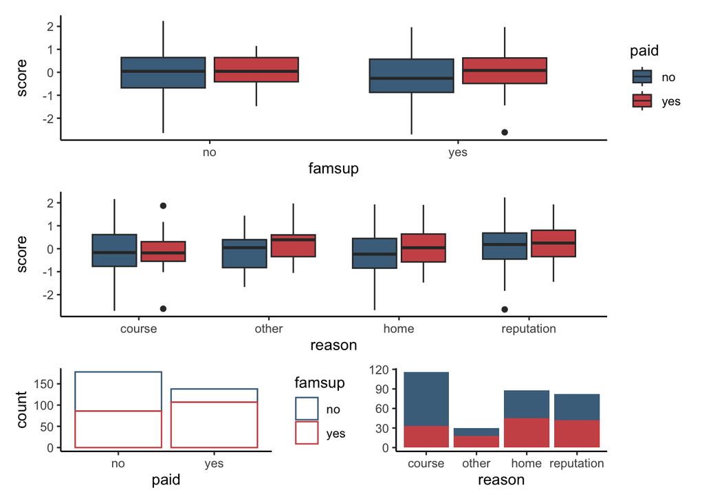

Score is not obviously associated with family support, neither with reason, while getting paid private lessons strongly reduces the spread of score. Students who don’t get paid lessons are generally the one with no family support and those whose reason is course. Overall, we only keep paid lessons in manual filtering.

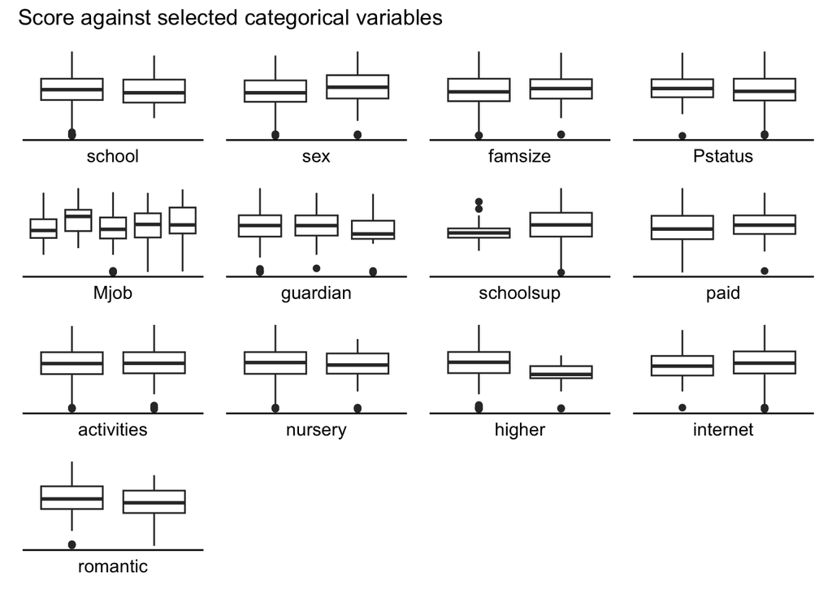

No significant effect pops out but we see that both school support and not willing to pursue in higher education reduce the spread of the score.

# Model description

We selected methods that can adapt a continuous predicted variable and predictors both categorical and numeric. We used :

I. Multiple linear regressions

Linear regression estimates the regression line by minimizing the sum of the squared distance between the points and the line. It does not have hyperparameters. The more variables/interactions included, the more the model is flexible. Feature selection was the main question here :

- in additive models : we first ran a model with all predictors, then one with manual filtering, then mix wrapper selection.
- in multiplicative models we were able to test models with a considerable number of parameters thanks to Lasso coefficients shrinkage. As we had categorical features, we used group Lasso. We used cross validation to tune lambda parameter.
2. KNN regression

KNN regression predicts for each point the average of its closest neighbors. The number of neighbors used is an hyperparameter, the smaller it is, the more the model is flexible.

3. Boosted tree

Boosted trees are built combining weak learners small trees, up-weighting unexplained observations at each round. This combination reduces the high bias of the isolated weak learners. There are several hyperparameters in xgboost, among which the number of rounds has a high impact on bias-variance trade-off (the more rounds the more variance).

4. Random forest tree

It is a bagged tree, i.e first very flexible large trees are fitted on different subsets of the rows, then variance is reduced by averaging them. Random forest also includes columns subsetting to avoid all trees to be similar. The number of selected columns is one of the several hyperparameters of the model.

# Data transformation and pre-processing

As shown before, absences and age are right skewed and will be log-transformed ; and mother and father education will be converted to factor class. We also generate another data frame where data are one hot encoded for Lasso and trees.

# Model comparison

## Model selection with train/dev/test

The baseline model will be the train score mean. The MSE will be used as a measure of fit since score is numeric.

When fitting a model to a data set, MSE mechanically decreases as model complexity increases. However, lower MSE in the train set don’t guarantee a better prediction of new data. This is because increasing model complexity can lead to adapt to random patterns in the train set, i.e overfitting. While model flexibility should be constrained to prevent it, simpler models can show bias in data prediction. Together, when model flexibility increases, these lead MSE in new data to first decrease as model bias decreases, then to increase as overfitting increases. Looking for the lowest new data MSE hence means performing a trade-off between bias and variance.

Such trade-off can be well implemented by applying a train/dev/test paradigm. We subset the data in :

- a train set, containing 80% of the rows , which will be used to fit the models. For models with hyperparameters, tuning will be performed by 5-fold cross-validation, which randomly and automatically subsets the train set itself.
- a test set, used to assess models performance and perform model selection.

## Models implementation

### Linear models

The additive linear model with all variables has an MSE of 0.86. Manually filtering the correlated features improves the MSE to 0.79 but we can go further with automated feature selection.

#### Automated selection in additive model with mix wrapper

```
Call:
lm(formula = paste(response, "~", paste(preds, collapse = " + ")),
    data = l)

Coefficients:
 (Intercept)      failures         goout          sexM   schoolsupno
     -0.1668       -0.4225       -0.1827        0.3606        0.3446
   studytime    Mjobhealth     Mjobother  Mjobservices   Mjobteacher
      0.1633        0.4481       -0.1249        0.1475        0.1069
```

```
[1] "Wrapper test MSE : 0.76"
```

The mix wrapper didn’t keep any feature we judged redundant during the EDA. A lot of the features it kept are also coherent with the one that appeared associated with score during the EDA, namely failures, going out, school support and study time. Mother’s job and sex come out in addition.

#### Multiplicative linear regression with Group Lasso

Remaining coefficients :

|  | outcome.outcome…1…..0… |
| --- | --- |
| (Intercept) | 0.2259867 |
| traveltime:famrel | -0.0018021 |
| studytime:famrel | 0.0161751 |
| studytime:freetime | 0.0089588 |
| studytime:absences | 0.0020487 |
| failures:famrel | -0.0012876 |
| failures:health | -0.0891015 |
| famrel:freetime | 0.0067933 |
| famrel:goout | -0.0243970 |
| famrel:address.R | -0.0005560 |
| famrel:Medu.4 | 0.0313461 |
| famrel:Fedu.4 | 0.0104028 |
| famrel:schoolsup.yes | -0.0324144 |
| famrel:romantic.yes | -0.0150188 |
| freetime:goout | -0.0087873 |
| freetime:sex.M | 0.0290241 |
| goout:health | -0.0052590 |
| health:absences | 0.0042632 |
| health:sex.F | -0.0205338 |
| health:sex.M | 0.0054566 |
| health:Mjob.other | -0.0144200 |

```
[1] "Group Lasso test MSE : 0.75"
```

### KNN with normalization: scaling and centering data before training the data

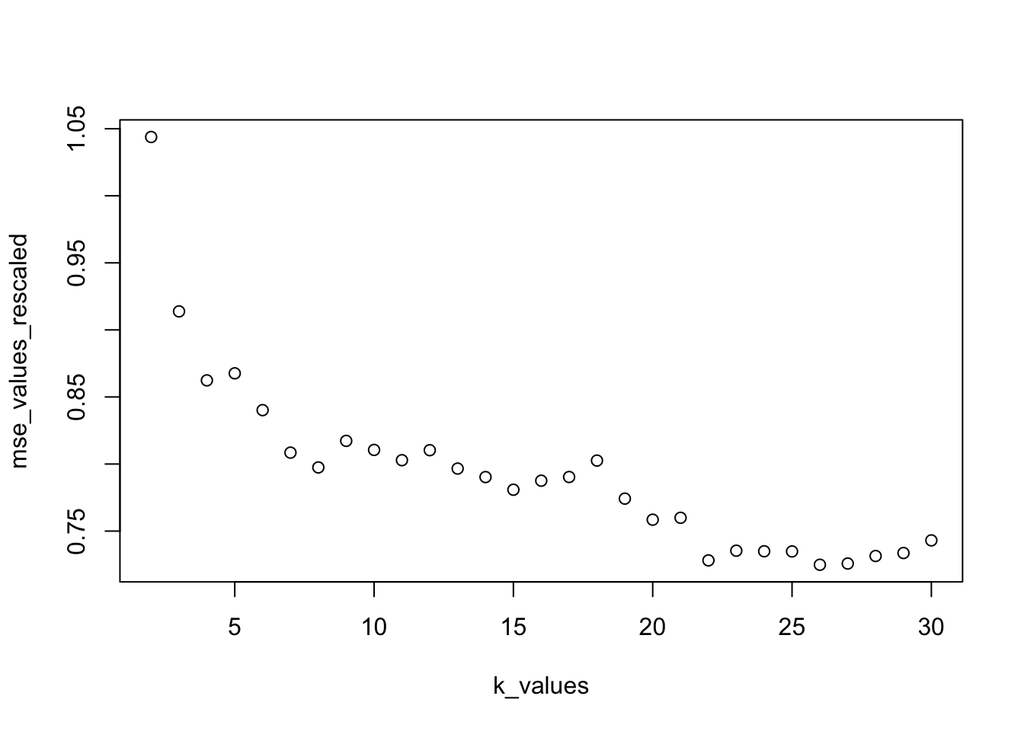

```
best number of neighbors is 26
 min test MSE is 0.72
```

We tried implementing KNN with all features but got better performance when reducing the dimensions to the variables identified during wraper feature selection. We kept only this model because we thought KNN is sensitive to dimensionality curse as is it based on the distance between each point and its neighbors. The KNN we chose is based on 26 neighbors, while the best KNN with all features has k = 14. Hence, this model likely has less variance and more bias.

### Boosted tree

```
boosted tree test MSE : 0.72
 number of rounds : 50
 (note that gamma and min child weight were not tuned)
```

### Random forest

```
random forest test MSE : 0.62
 split rule : 1
 selected predictors 64
 (note that min node size was not tuned)
```

# Chosen model

## Test MSE comparison

Test MSE showed to be very sensible to the seed applied to the train-test partioning step, for all models including the mean baseline. This likely suggest that the number of records we have is low compared to the variance in the data.

```
 baseline full.add.linreg wrap.add.linreg Lasso.mult.linreg KNN.norm.selec
     1.02            0.86            0.76              0.75           0.72
 xboost.tree rand.forest
        0.72        0.62
```

## Chosen model visualization

We chose the model with the lowest test mean squared error: the random forest.

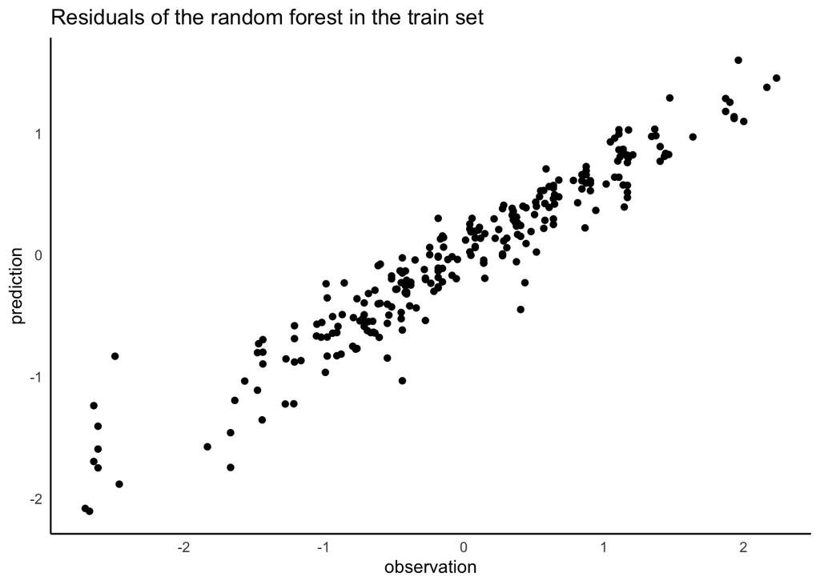

Overall the random forest fits well the train set, except for a few very low scores that are overestimated.